# NBA Project

2024-05-30

# Introduction

In the NBA, the three-point shot has quickly become one of the most important aspects of winning games and as a result, finding players who are either currently elite at shooting threes or have tools which will lead to proficiency are of the utmost importance. So how can we predict future shooting success based on information from a player’s college career?

|  | Name | School | G | FGMade | FGPercentage | TwosMade | TwoPercentage | ThreesAttempted | ThreePercentage | FTMade | FTPercentage | NBAThreePercentage |
| --- | --- | --- | --- | --- | --- | --- | --- | --- | --- | --- | --- | --- |
| 1 | Joel Embiid | Kansas | 28 | 3.8 | 0.626 | 5.9 | 0.639 | 0.2 | 0.200 | 3.5 | 0.685 | 0.341 |
| 2 | Damian Lillard | Weber State | 104 | 5.6 | 0.446 | 6.5 | 0.497 | 6.1 | 0.390 | 5.0 | 0.867 | 0.371 |
| 3 | Shai Gilgeous-Alexander | Kentucky | 37 | 4.9 | 0.485 | 8.6 | 0.500 | 1.5 | 0.404 | 3.9 | 0.817 | 0.349 |
| 4 | Jayson Tatum | Duke | 29 | 5.7 | 0.452 | 8.6 | 0.504 | 4.0 | 0.342 | 4.1 | 0.849 | 0.375 |
| 5 | Donovan Mitchell | Louisville | 65 | 4.1 | 0.418 | 5.2 | 0.497 | 4.6 | 0.329 | 2.0 | 0.788 | 0.366 |

Our created dataset (reduced for space above) consists of every active NBA player who played at least 1 year in NCAA colleges. All non-percentage statistics are on a per-game basis, and the last column reveals each player’s actual NBA 3-point percentage (as of the end of the 2023-24 season). Can this information reveal what aspects differentiates a good NBA shooter from a bad one?

The NBA 3-point percentage of each player was scraped from Basketball Reference (https://www.basketball-reference.com/), a comprehensive website consisting of every team, player, and season of the NBA and its sister leagues. College statistics for each player were scraped from Sports Reference’s College Basketball section (https://www.sports-reference.com/cbb/), owned by the same umbrella company.

One aspect missing from this dataset occurs with International players: While of some of these players would attend an NCAA university (and is therefore represented in this dataset), many joined the NBA directly after playing in European or other international leagues, of which statistics are inconsistent and difficult to obtain manually. As such, most international players, mainly from Europe, are absent from this dataset.

# Exploratory Data Analysis

Our first thought should be using basic logic to say a player’s three-point percentage in college should be a strong indicator of their three-point percentage. However, as with most things in sports, past performance rarely dictates (or predicts) future performance. If we take a look at the distributions of both statistics, we come across an interesting result:

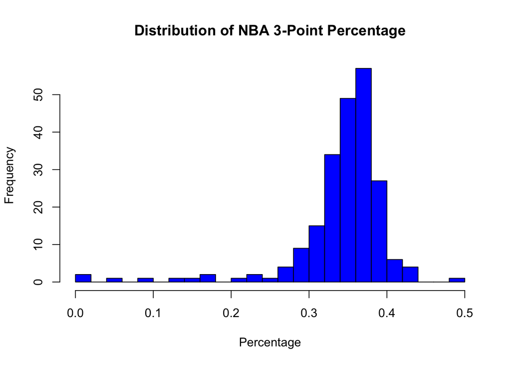

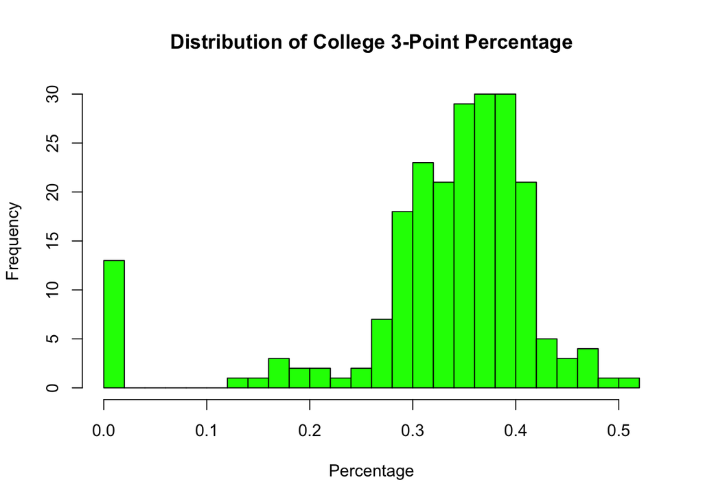

Despite the players of both graphs being the same, college 3-point percentages have a much wider distribution compared to their NBA counterpart. This actually makes complete sense; college players who make the NBA typically only spend 1 or 2 teenage years playing around 30 games a season. Factors such as young players with undeveloped jumpshots, low sample size, and other developmental variables result in an unreliable indicator of who can actually shoot at a higher level. As a matter of fact, when we plot NBA 3-point percentage versus College 3-point percentage…

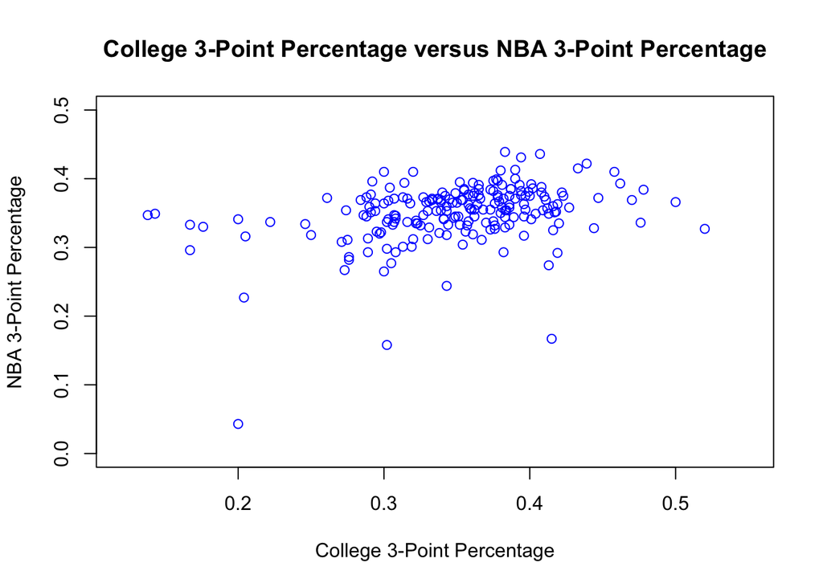

We find there to be no real correlation, at all. A majority of these players hover around 35% (around the league average), regardless of what they shot in college.

Traditional basketball wisdom points towards another, more consistent indicator of NBA three-point percentage: Free Throw percentage. This effectively measures the consistency and effectiveness of a player’s jumpshot mechanics in as close to a vacuum as possible. A high free throw percentage typically means you have repeatable elite mechanics, and a low free throw percentage the exact opposite. If we plot these two variables against each other…

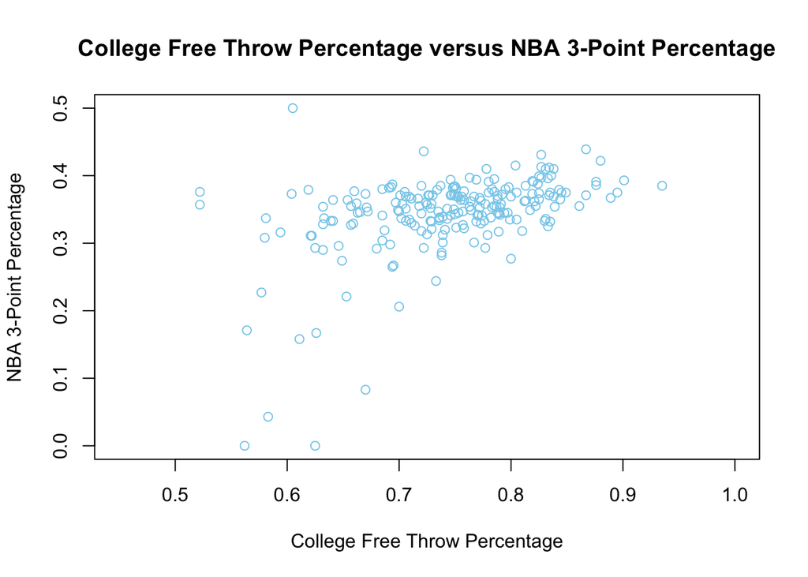

We start to find a real positive correlation between them.

I want to make one more plot, just to show that numbers don’t really mean anything if have a fundamental misunderstanding of their context. Here is field-goal percentage (all made shots over all made attempts) versus NBA 3-point percentage:

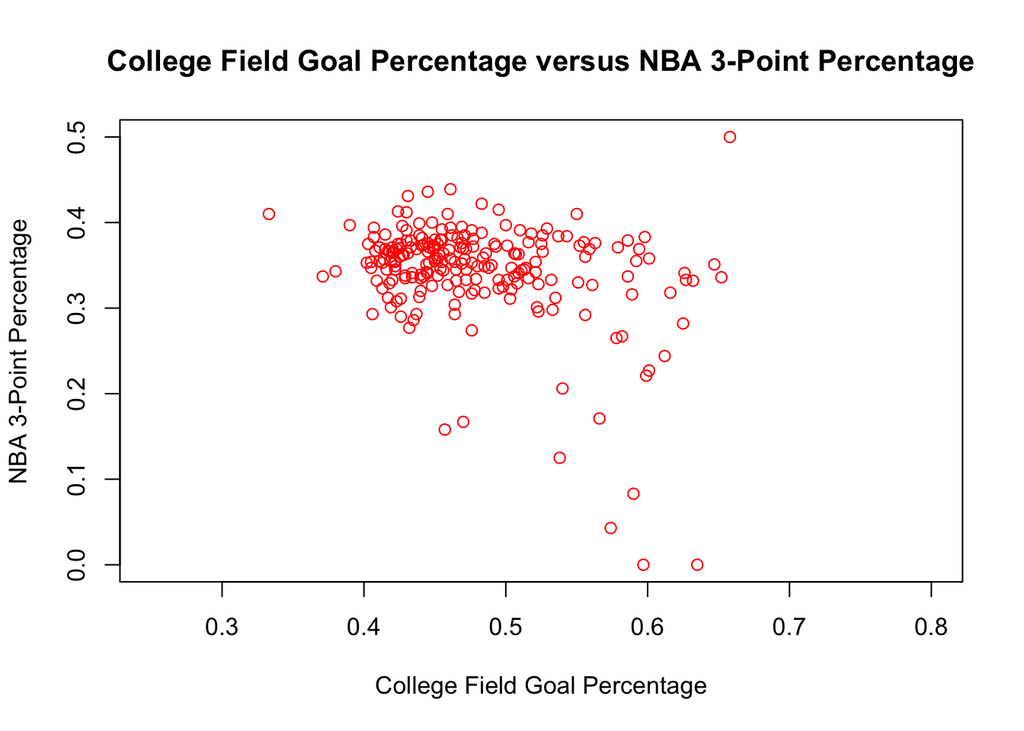

At first, this makes no sense. Three-pointers are field goals, so making more field goals should make it more likely your 3-point percentage is high. However, this logic neglects the idea of a shot’s quality: shots closer to the basket have a higher expected make percentage, and therefore players who are worse at shooting threes will take easier, more makeable shots resulting in a higher field goal percentage.

# Data Splitting, Cross Validation

Now that we’ve gone over what our dataset consists of and what exactly we are looking for, we should now review how our data will be processed. Out of the 218 players provided, I have split the data 80-20% between training data (used to fit our potential models) and testing data (used for a final evaluation of any models selected). This data is split using the player’s NBA’s 3-Point Percentage as a strata in order to ensure our models are fit on representative data.

We will then use k-fold cross validation, with K set to 5. This helps create numerous validation sets: A set within the training data which we can use to test our fitted models. K-fold cross validation divides our training data in to K (in this case 5) sections, 4 of which will be used to fit the models and the final one to validate the fit. This rotates 5 times until every section is used as a validation set.

```r
set.seed(21)
nbasplit <- initial_split(totalstats, prop = 0.8, strata = NBAThreePercentage)
nbatraining <- training(nbasplit)
nbatesting <- testing(nbasplit)
nbafolds <- vfold_cv(nbatraining, v = 5, strata = NBAThreePercentage)
```

#Model Fitting

We first create our recipe, which I have decided to be all numeric provided variables in the dataset as predictors against NBA 3-point percentage. When initially creating the dataset, I manually omitted other measured statistics I believed had little to do with shooting ability (defensive/passing statistics, etc.) therefore resulting in almost all variables remaining being relevant to our leading question.

I have set up 4 types of models to test:

```r
nbarecipe <- recipe(NBAThreePercentage ~ FGMade + FGAttempted + FGPercentage +
                    TwosMade + TwosAttempted + TwoPercentage + ThreesMade +
                    ThreesAttempted + ThreePercentage + FTMade + FTAttempted +
                    FTPercentage, data = totalstats)  %>%
  step_dummy(all_nominal_predictors()) %>%
  step_center(all_predictors()) %>%
  step_scale(all_predictors())

linearmodel <- linear_reg() %>%
  set_engine("lm") %>%
  set_mode("regression")

linearworkflow <- workflow() %>%
  add_model(linearmodel) %>%
  add_recipe(nbarecipe)

knnmodel <- nearest_neighbor(weight_func = "rectangular", neighbors = tune()) %>%
  set_engine("kknn") %>%
  set_mode("regression")

knnworkflow <- workflow() %>%
  add_model(knnmodel) %>%
  add_recipe(nbarecipe)

elasticmodel <- linear_reg(mixture = tune(), penalty = tune()) %>%
  set_mode("regression") %>%
  set_engine("glmnet")

elasticworkflow <- workflow() %>%
  add_model(elasticmodel) %>%
  add_recipe(nbarecipe)

forestmodel <- rand_forest(
  mtry = tune(),
  trees = tune(),
  min_n = tune()) %>%
  set_engine("ranger") %>%
  set_mode("regression")

forestworkflow <- workflow() %>%
  add_recipe(nbarecipe) %>%
  add_model(forestmodel)

neighborsgrid <- grid_regular(neighbors(range = c(1, 10)), levels = 10)
elasticgrid <- grid_regular(penalty(range = c(0, 1), trans = identity_trans()),
                            mixture(range = c(0, 1)), levels = 10)

forestgrid <- grid_regular(
  mtry(range = c(5, 12)),
  trees(range = c(50, 500)),
  min_n(range = c(1, 20)),
  levels = 8)
```

After setting up our models and workflows, we then tune all four of our models using our validation sets produced by K-fold cross-validation.

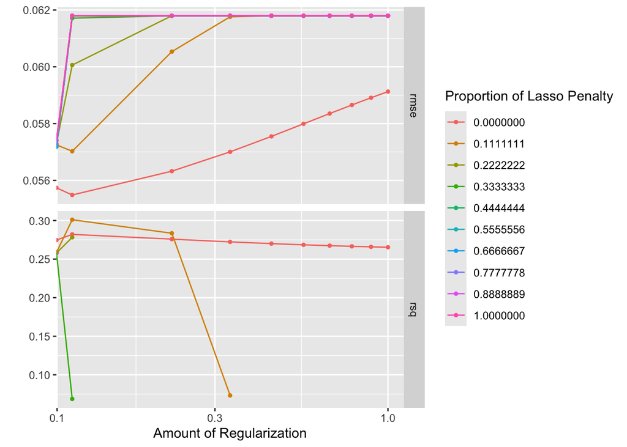

```r
autoplot(tuneelastic)
```

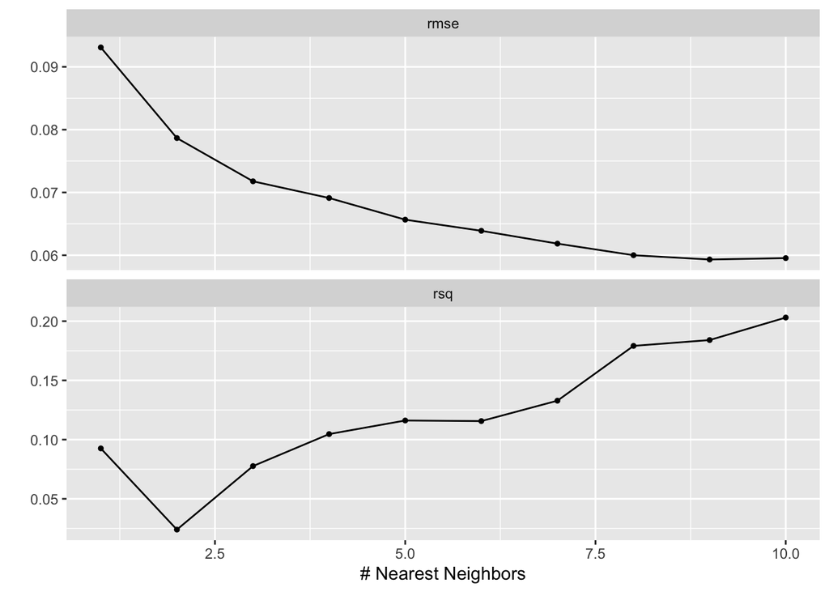

```r
autoplot(tuneknn)
```

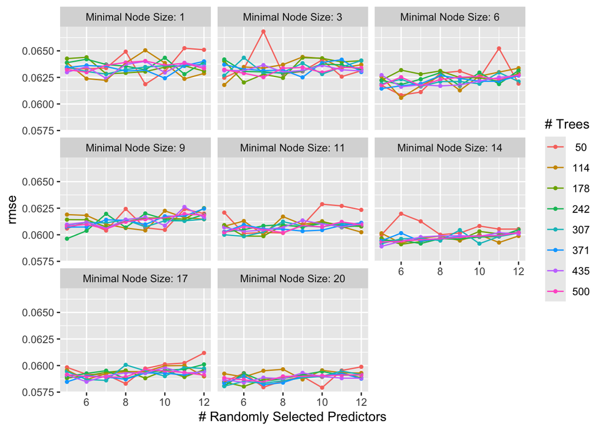

```r
autoplot(tuneforest)
```

The results of tuning our models (if necessary) are present in the graphs above.

# Model Selection

We can now measure how well each of these models did on each validation set. While there are a number of metrics one can use, I am using RMSE (Root Mean Squared Error).

| neighbors | .metric | .estimator | mean | n | std_err | .config |
| --- | --- | --- | --- | --- | --- | --- |
| 9 | rmse | standard | 0.05931985 | 5 | 0.008138846 | Preprocessor1_Model09 |

| .metric | .estimator | mean | n | std_err | .config |
| --- | --- | --- | --- | --- | --- |
| rmse | standard | 0.05761613 | 5 | 0.007511637 | Preprocessor1_Model1 |

| penalty | mixture | .metric | .estimator | mean | n | std_err | .config |
| --- | --- | --- | --- | --- | --- | --- | --- |
| 0.1111111 | 0 | rmse | standard | 0.0554843 | 5 | 0.008374763 | Preprocessor1_Model002 |

| mtry | trees | min_n | .metric | .estimator | mean | n | std_err | .config |
| --- | --- | --- | --- | --- | --- | --- | --- | --- |
| 10 | 50 | 20 | rmse | standard | 0.05791989 | 5 | 0.007352971 | Preprocessor1_Model454 |

As mentioned earlier, our best models for elastic net regression and K-Nearest Neighbors come at a Penalty and Mixture of .11 and 0 and a K set to 9, respectively. However, I’ve selected to use our linear model going forward, due to its relatively low RMSE mean and standard error. My second choice would have been the Elastic Net Regression.

# Final Model Performance

```r
head(trainingresults[keeps][order(trainingresults$.pred, decreasing = TRUE), ], 5)
```

| Name | School | G | FGMade | FGPercentage | TwosMade | TwoPercentage | ThreesAttempted | ThreePercentage | FTMade | FTPercentage | NBAThreePercentage |
| --- | --- | --- | --- | --- | --- | --- | --- | --- | --- | --- | --- |
| Sam Hauser | Overall | 126 | 4.7 | 0.483 | 4.1 | 0.543 | 5.6 | 0.439 | 1.5 | 0.880 | 0.422 |
| Tyler Herro | Kentucky | 37 | 5.0 | 0.462 | 6.3 | 0.538 | 4.6 | 0.355 | 2.4 | 0.935 | 0.385 |
| Mikal Bridges | Villanova | 116 | 3.9 | 0.525 | 3.8 | 0.645 | 3.7 | 0.400 | 1.9 | 0.845 | 0.375 |
| Corey Kispert | Gonzaga | 137 | 4.1 | 0.483 | 3.6 | 0.585 | 4.8 | 0.408 | 1.5 | 0.824 | 0.388 |
| Buddy Hield | Oklahoma | 132 | 5.9 | 0.448 | 6.5 | 0.508 | 6.8 | 0.390 | 2.8 | 0.836 | 0.400 |

As we can see, our model is capable of predicting NBA players’ career 3-point percentage within approximately a 1-percent margin of error. However, if we look at our Fitted versus Residual plot for our training data:

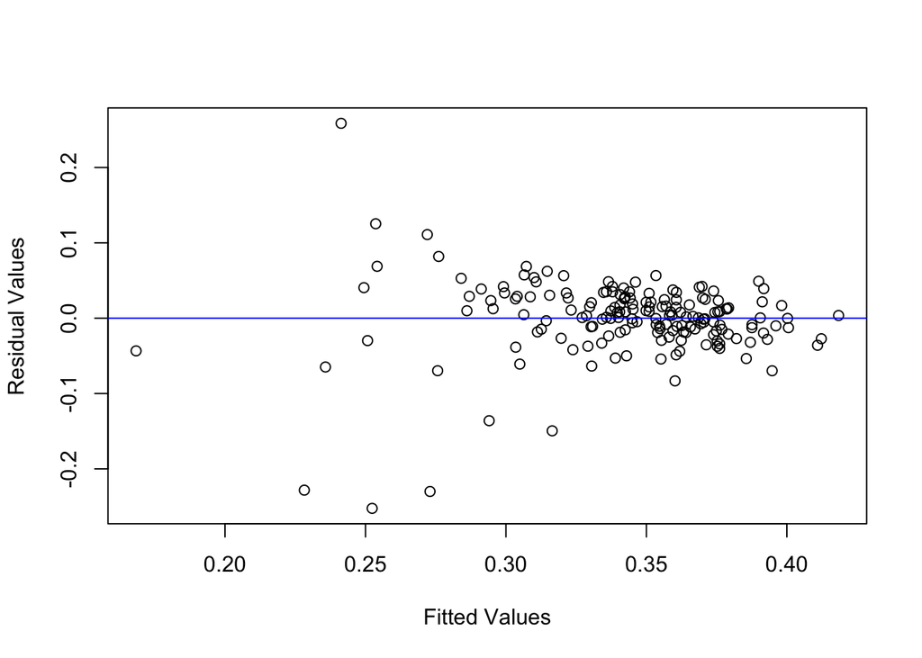

```r
plot(x = trainingresults$.pred, y = trainingresults$.resid, xlab = "Fitted Values",
     ylab = "Residual Values")
abline(h = 0, col = "Blue")
```

We see several extremely high residuals in both directions. This can be attributed to NBA players who take threes on extremely low volume and therefore have an unreliable percentage. If we remove such cases, we then have…

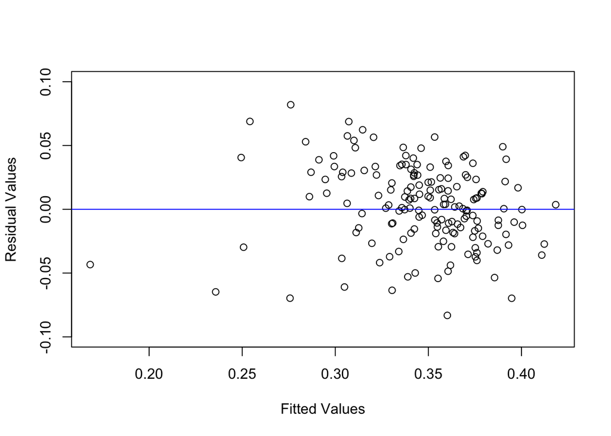

The vast majority of remaining players being quite accurately calculated.

We will now use this model on our testing data.

```r
testingresults <- augment(nbafinal, new_data = nbatesting)
head(testingresults[keeps][order(testingresults$.pred, decreasing = TRUE), ], 5)
```

| Name | School | G | FGMade | FGPercentage | TwosMade | TwoPercentage | ThreesAttempted | ThreePercentage | FTMade | FTPercentage | NBAThreePercentage |
| --- | --- | --- | --- | --- | --- | --- | --- | --- | --- | --- | --- |
| Trey Murphy III | Overall | 86 | 3.6 | 0.455 | 2.4 | 0.580 | 5.5 | 0.401 | 1.6 | 0.819 | 0.392 |
| Jamal Murray | Kentucky | 36 | 6.8 | 0.454 | 7.3 | 0.502 | 7.7 | 0.408 | 3.3 | 0.783 | 0.380 |
| Lauri Markkanen | Arizona | 37 | 5.0 | 0.492 | 5.8 | 0.545 | 4.4 | 0.423 | 3.7 | 0.835 | 0.375 |
| Damian Lillard | Weber State | 104 | 5.6 | 0.446 | 6.5 | 0.497 | 6.1 | 0.390 | 5.0 | 0.867 | 0.371 |
| Aaron Nesmith | Vanderbilt | 46 | 4.8 | 0.442 | 4.5 | 0.485 | 6.3 | 0.410 | 2.6 | 0.825 | 0.374 |

```r
testrmse <- rmse(testingresults, truth = NBAThreePercentage, estimate = .pred)
testrmse
```

| .metric | .estimator | .estimate |
| --- | --- | --- |
| rmse | standard | 0.04453149 |

We can see that our test RMSE is actually lower than our training RMSE.

We will now use a variable importance plot in order to discover which statistics in our linear regression are most key to determine a player’s NBA 3-point percentage.

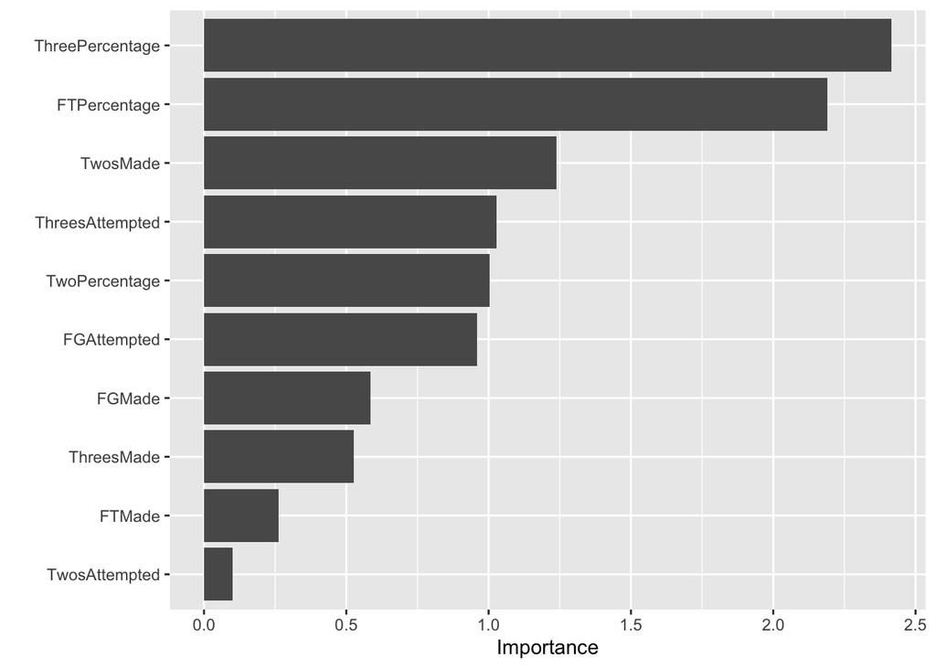

```r
vip(nbafinal)
```

Despite what we originally mentioned in the first section, the most important variable was, in fact, college 3-point percentage. This shows us that the statistic itself can be telling, but other factors must also be taken into account.

Free Throw Percentage comes in second, proving the traditional adage correct. Something I find particularly surprising is Two-Pointers Made being third; this may simply be a matter of correlation not equal to causation (especially since Two-Pointers Attempted being the least important variable), but it is still incredibly interesting.

If we take a look at a graph of Predicted 3-Point Percentage vs. True 3-Point Percentage, we will see a decent correlation.

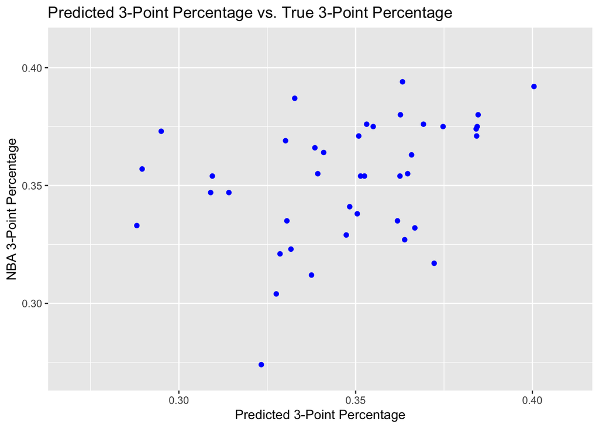

# Conclusion

How could this be potentially used by NBA front offices, looking to find either the next 3-point shooting star or potentially an extremely undervalued candidate? This would a tool used in conjunction with (not replacing) traditional scouts, who value a player’s performance visually along with other, less quantifiable intangibles. One positive mark of our model’s performance is being able to spot players who were initially undervalued by the league. In our training set, Sam Hauser was ranked as the top shooter of all players, but was one of the last draft picks of his college class. Another, Gabe Vincent, was overlooked by all teams, going undrafted, before having a long career. Tools like these are may very likely be the future of evaluating NBA prospects in all aspects.

Bibliography:

Sports Reference LLC. Basketball-Reference.com - Basketball Statistics and History. https://www.basketball-reference.com/. 5/30/2024.

Sports Reference LLC. Sports-Reference.com - College Basketball Statistics and History. https://www.sports-reference.com/cbb/. 5/30/2024.